# loan_defaulter_prediction_pre-processing

### AMT_CREDIT

```python
dff['AMT_CREDIT'].head()
```

```
0     406597.5
1    1293502.5
2     135000.0
3     312682.5
4     513000.0
Name: AMT_CREDIT, dtype: float64
```

```python
dff['AMT_CREDIT'].isnull().sum()*100/len(dff['AMT_CREDIT'])
```

```
0.0
```

```python
skewness = dff['AMT_CREDIT'].skew()
kurtosis = dff['AMT_CREDIT'].kurt()
print('Skewness',skewness)
print('Kurtosis',kurtosis)
```

```
Skewness 1.2347784971349398
Kurtosis 1.9340413008324937
```

```python
dff['LOG_AMT_CREDIT'] = np.log(dff['AMT_CREDIT'])
```

```python
dff['LOG_AMT_CREDIT'].skew()
```

```
-0.3388232381048932
```

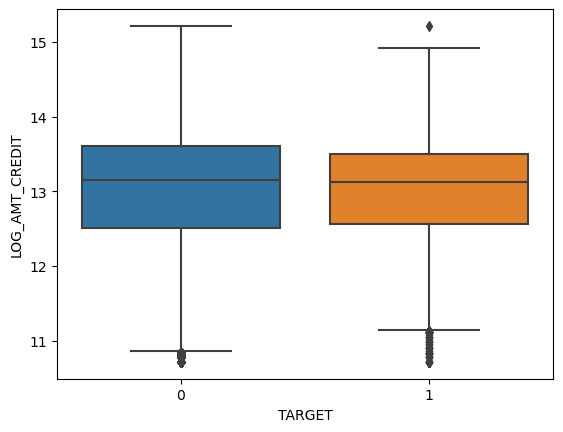

```python
sns.boxplot(x=('TARGET'),y=('LOG_AMT_CREDIT'),data=dff)
```

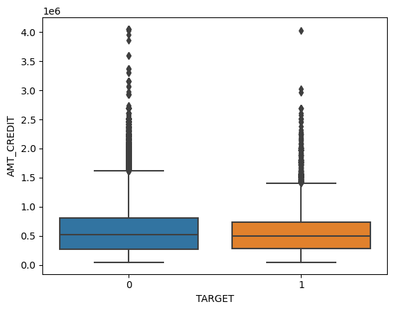

```python
sns.boxplot(x=('TARGET'),y=('AMT_CREDIT'),data=dff)
```

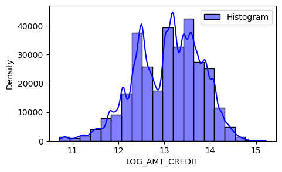

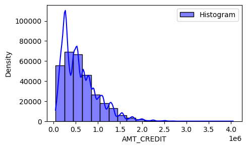

```python
plt.figure(figsize=(5, 3))
sns.histplot(data=dff, x='LOG_AMT_CREDIT', bins=20, kde=True, color='blue', label='Histogram')
plt.xlabel('LOG_AMT_CREDIT')
plt.ylabel('Density')
plt.legend()
plt.show()

plt.figure(figsize=(5, 3))
sns.histplot(data=dff, x='AMT_CREDIT', bins=20, kde=True, color='blue', label='Histogram')
plt.xlabel('AMT_CREDIT')
plt.ylabel('Density')
plt.legend()
plt.show()
```

```python
dff['TARGET'].head()
```

```
0    1
1    0
2    0
3    0
4    0
Name: TARGET, dtype: int64
```

```python
pd.pivot_table(data=dff,values='AMT_CREDIT',index='TARGET',aggfunc='mean')
```

| TARGET | AMT_CREDIT |
| --- | --- |
| 0 | 602648.282002 |
| 1 | 557778.527674 |

```python
a=dff[dff['TARGET'] == 1]['LOG_AMT_CREDIT']
```

```python
b=dff[dff['TARGET'] == 0]['LOG_AMT_CREDIT']
```

HYPOTHESIS

Ho : No relation between AMT_CREDIT and TARGET columns Ha : Relationship exist between AMT_CREDIT and TARGET columns

```python
stats.shapiro(a)
```

```
ShapiroResult(statistic=0.9909209949792724, pvalue=3.094864436079834e-36)
```

```python
stats.f_oneway(a,b)
```

```
F_onewayResult(statistic=45.63494233190198, pvalue=1.4272902742791389e-11)
```

```python
stats.kruskal(a,b)
```

```
KruskalResult(statistic=94.57467370661574, pvalue=2.36018795179332e-22)
```

#### p-value is very less (of the order of -22) and hence < 0.05. Hence reject the null hypothesis.

#### Thus there is a significant relationship between AMT_CREDIT and TARGET columns

### AMT_ANNUITY

```python
dff['AMT_ANNUITY'].head()
```

```
0    24700.5
1    35698.5
2     6750.0
3    29686.5
4    21865.5
Name: AMT_ANNUITY, dtype: float64
```

```python
dff['AMT_ANNUITY'].isnull().sum()
```

```
12
```

```python
dff['AMT_ANNUITY'].isnull().sum()*100/len(dff['AMT_ANNUITY'])
```

```
0.0039022994299390914
```

```python
skewness = dff['AMT_ANNUITY'].skew()
kurtosis = dff['AMT_ANNUITY'].kurt()
print('Skewness',skewness)
print('Kurtosis',kurtosis)
```

```
Skewness 1.5797773638612507
Kurtosis 7.707319914804311
```

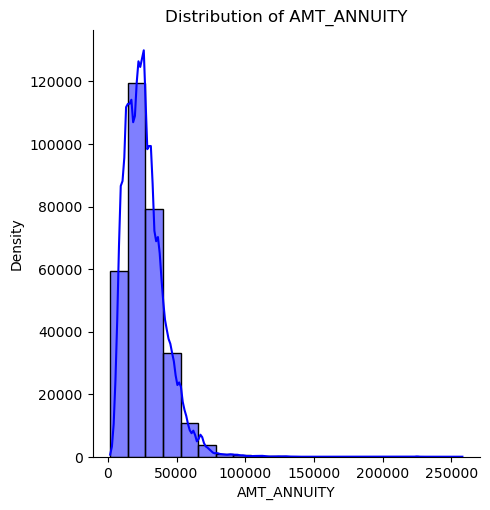

```python
plt.figure(figsize=(5, 3))
sns.displot(data=dff, x='AMT_ANNUITY', bins=20, kde=True, color='blue')
plt.xlabel('AMT_ANNUITY')
plt.ylabel('Density')
plt.title('Distribution of AMT_ANNUITY')
plt.show()
```

```python
dff['LOG_AMT_ANNUITY'] = np.log(dff['AMT_ANNUITY'])
```

```python
dff['LOG_AMT_ANNUITY'].skew()
```

```
-0.345744882775657
```

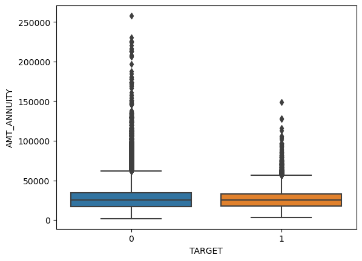

```python
sns.boxplot(x=('TARGET'),y=('AMT_ANNUITY'),data=dff)
```

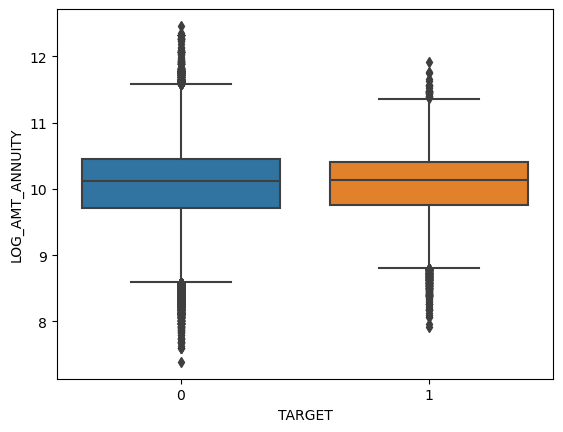

```python
sns.boxplot(x=('TARGET'),y=('LOG_AMT_ANNUITY'),data=dff)
```

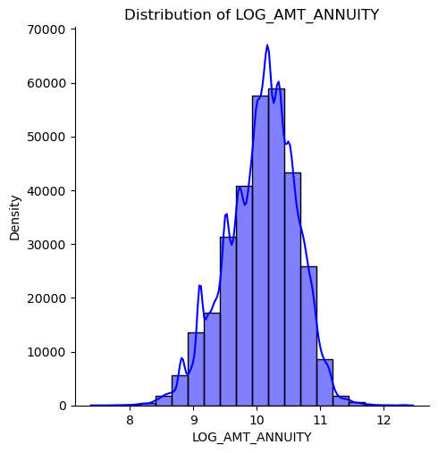

```python
plt.figure(figsize=(5, 3))
sns.displot(data=dff, x='LOG_AMT_ANNUITY', bins=20, kde=True, color='blue')
plt.xlabel('LOG_AMT_ANNUITY')
plt.ylabel('Density')
plt.title('Distribution of LOG_AMT_ANNUITY')
plt.show()
```

```python
pd.pivot_table(data=dff,values='AMT_ANNUITY',index='TARGET',aggfunc='mean')
```

| TARGET | AMT_ANNUITY |
| --- | --- |
| 0 | 27163.623349 |
| 1 | 26481.744290 |

```python
a=dff[dff['TARGET']==1]['AMT_ANNUITY']
```

```python
b=dff[dff['TARGET'] ==0]['AMT_ANNUITY']
```

```python
c=dff[dff['TARGET']==1]['LOG_AMT_ANNUITY']
```

```python
d=dff[dff['TARGET'] ==0]['LOG_AMT_ANNUITY']
```

```python
a = a[~np.isnan(a)]
b = b[~np.isnan(b)]
```

```python
c = c[~np.isnan(c)]
d = d[~np.isnan(d)]
```

HYPOTHESIS

Ho : No relation between AMT_ANNUITY and TARGET columns Ha : Relationship exist between AMT_ANNUITY and TARGET columns

```python
# Levene's Test in Python using Pingouin
pg.homoscedasticity(dff, dv='TARGET', group='AMT_ANNUITY')
```

|  | W | pval | equal_var |
| --- | --- | --- | --- |
| levene | 1.381227 | 4.639766e-166 | False |

```python
stats.mannwhitneyu(a,b)
```

```
MannwhitneyuResult(statistic=3508145704.0, pvalue=0.9675618300626294)
```

```python
a.head()
```

```
0     24700.5
26    27076.5
40    35028.0
42    16258.5
81    14593.5
Name: AMT_ANNUITY, dtype: float64
```

```python
# Levene's Test in Python using Pingouin
pg.homoscedasticity(dff, dv='TARGET', group='LOG_AMT_ANNUITY')
```

|  | W | pval | equal_var |
| --- | --- | --- | --- |
| levene | 1.381227 | 4.639766e-166 | False |

```python
stats.mannwhitneyu(c,d)
```

```
MannwhitneyuResult(statistic=3508145704.0, pvalue=0.9675618300626294)
```

#### p-value 0.96 > 0.05. Hence failed to reject the null hypothesis.

#### Thus there is no significant relationship between AMT_ANNUITY and TARGET columns

### AMT_GOODS_PRICE

```python
dff['AMT_GOODS_PRICE'].head()
```

```
0     351000.0
1    1129500.0
2     135000.0
3     297000.0
4     513000.0
Name: AMT_GOODS_PRICE, dtype: float64
```

```python
dff['AMT_GOODS_PRICE'].isnull().sum()
```

```
278
```

```python
dff['AMT_GOODS_PRICE'].isnull().sum()*100/len(dff['AMT_GOODS_PRICE'])
```

```
0.09040327012692229
```

```python
skewness = dff['AMT_GOODS_PRICE'].skew()
kurtosis = dff['AMT_GOODS_PRICE'].kurt()
print('Skewness',skewness)
print('Kurtosis',kurtosis)
```

```
Skewness 1.3490003414747445
Kurtosis 2.4319164792166954
```

```python
dff['LOG_AMT_GOODS_PRICE'] = np.log(dff['AMT_GOODS_PRICE'])
```

```python
dff['LOG_AMT_GOODS_PRICE'].skew()
```

```
-0.29295288397058666
```

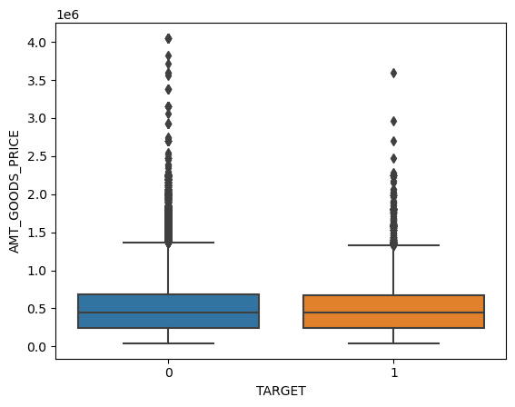

```python
sns.boxplot(x=('TARGET'),y=('AMT_GOODS_PRICE'),data=dff)
```

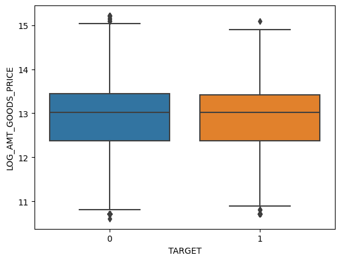

```python
sns.boxplot(x=('TARGET'),y=('LOG_AMT_GOODS_PRICE'),data=dff)
```

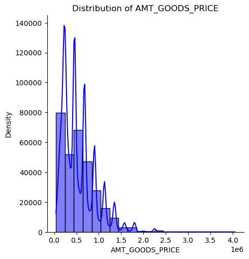

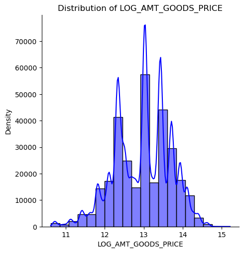

```python
plt.figure(figsize=(5,3))
sns.displot(data=dff, x='AMT_GOODS_PRICE', bins=20, kde=True, color='blue')
plt.xlabel('AMT_GOODS_PRICE')
plt.ylabel('Density')
plt.title('Distribution of AMT_GOODS_PRICE')
plt.show()

plt.figure(figsize=(5,3))
sns.displot(data=dff, x='LOG_AMT_GOODS_PRICE', bins=20, kde=True, color='blue')
plt.xlabel('LOG_AMT_GOODS_PRICE')
plt.ylabel('Density')
plt.title('Distribution of LOG_AMT_GOODS_PRICE')
plt.show()
```

```python
pd.pivot_table(data=dff,values='AMT_GOODS_PRICE',index='TARGET',aggfunc='mean')
```

| TARGET | AMT_GOODS_PRICE |
| --- | --- |
| 0 | 542736.795003 |
| 1 | 488972.412554 |

```python
e=dff[dff['TARGET']==1]['AMT_GOODS_PRICE']
```

```python
f=dff[dff['TARGET']==0]['AMT_GOODS_PRICE']
```

```python
e = e[~np.isnan(e)]
f = f[~np.isnan(f)]
```

HYPOTHESIS

Ho : No relation between AMT_GOODS_PRICE and TARGET columns Ha : Relationship exist between AMT_GOODS_PRICE and TARGET columns

```python
# Levene's Test in Python using Pingouin
pg.homoscedasticity(dff, dv='TARGET', group='AMT_GOODS_PRICE')
```

|  | W | pval | equal_var |
| --- | --- | --- | --- |
| levene | 3.191305 | 3.391426e-225 | False |

```python
stats.mannwhitneyu(e,f)
```

```
MannwhitneyuResult(statistic=3269141680.0, pvalue=3.094323682243968e-68)
```

#### p-value is very less (of the order of -68) and hence < 0.05. Hence reject the null hypothesis.

#### Thus there is a significant relationship between AMT_GOODS_PRICE and TARGET columns

### NAME_INCOME_TYPE

```python
dff['NAME_INCOME_TYPE'].head()
```

```
0          Working
1    State servant
2          Working
3          Working
4          Working
Name: NAME_INCOME_TYPE, dtype: object
```

```python
table=pd.crosstab(dff['NAME_INCOME_TYPE'],dff['TARGET'])
table
```

| TARGET NAME_INCOME_TYPE | 0 | 1 |
| --- | --- | --- |
| Businessman | 10 | 0 |
| Commercial associate | 66257 | 5360 |
| Maternity leave | 3 | 2 |
| Pensioner | 52380 | 2982 |
| State servant | 20454 | 1249 |
| Student | 18 | 0 |
| Unemployed | 14 | 8 |
| Working | 143550 | 15224 |

```python
observed_value=table.values
observed_value
```

```
array([[    10,      0],
       [ 66257,   5360],
       [     3,      2],
       [ 52380,   2982],
       [ 20454,   1249],
       [    18,      0],
       [    14,      8],
       [143550,  15224]], dtype=int64)
```

HYPOTHESIS

Ho : No relation between NAME_INCOME_TYPE and TARGET columns Ha : Relationship exist between NAME_INCOME_TYPE and TARGET columns

```python
stats.chi2_contingency(observed= observed_value)
```

```
Chi2ContingencyResult(statistic=1253.4708080924986, pvalue=1.9281456056861122e-266, dof=7, expected_freq=array([[9.19271181e+00, 8.07288195e-01],
       [6.58354441e+04, 5.78155586e+03],
       [4.59635590e+00, 4.03644097e-01],
       [5.08926911e+04, 4.46930890e+03],
       [1.99509424e+04, 1.75205757e+03],
       [1.65468812e+01, 1.45311875e+00],
       [2.02239660e+01, 1.77603403e+00],
       [1.45956362e+05, 1.28176376e+04]]))
```

#### p-value is very less (of the order of -266) and hence < 0.05. Hence reject the null hypothesis.

#### Thus there is a significant relationship between NAME_INCOME_TYPE and TARGET columns

```python
dff['NAME_INCOME_TYPE'].isnull().sum()*100/len(dff['NAME_INCOME_TYPE'])
```

```
0.0
```

```python
dff['NAME_INCOME_TYPE'].value_counts()
```

```
NAME_INCOME_TYPE
Working                 158774
Commercial associate     71617
Pensioner                55362
State servant            21703
Unemployed                  22
Student                     18
Businessman                 10
Maternity leave              5
Name: count, dtype: int64
```

```python
(dff.groupby(['NAME_INCOME_TYPE'])['TARGET'].sum()/dff['NAME_INCOME_TYPE'].value_counts())*100
```

```
NAME_INCOME_TYPE
Businessman              0.000000
Commercial associate     7.484257
Maternity leave         40.000000
Pensioner                5.386366
State servant            5.754965
Student                  0.000000
Unemployed              36.363636
Working                  9.588472
dtype: float64
```

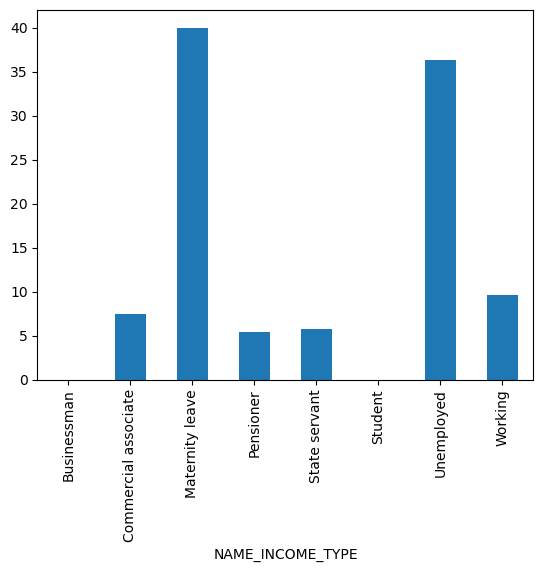

```python
((dff.groupby(['NAME_INCOME_TYPE'])['TARGET'].sum()/dff['NAME_INCOME_TYPE'].value_counts())*100).plot(kind='bar')
```

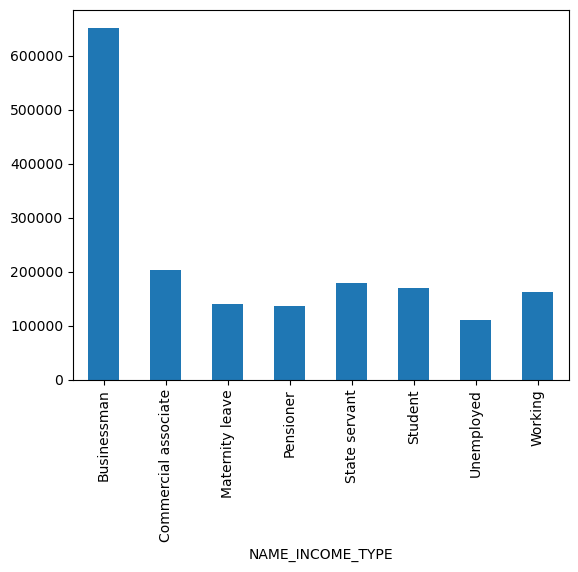

```python
dff.groupby('NAME_INCOME_TYPE')['AMT_INCOME_TOTAL'].mean().plot(kind='bar')
plt.show()
```

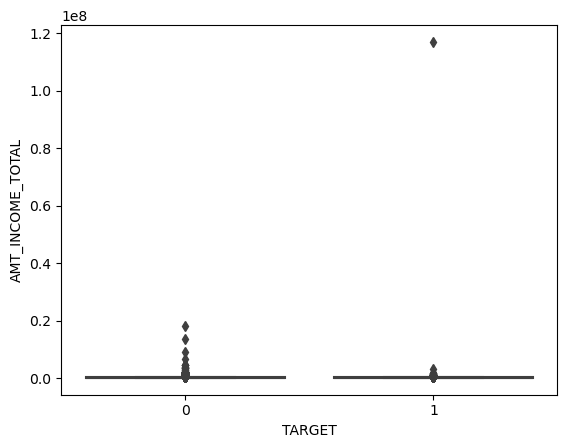

```python
sns.boxplot(x=('TARGET'),y=('AMT_INCOME_TOTAL'),data=dff)
```

```python
#How to treat this?
```

### NAME_EDUCATION_TYPE

```python
dff['NAME_EDUCATION_TYPE'].head()
```

```
0    Secondary / secondary special
1                 Higher education
2    Secondary / secondary special
3    Secondary / secondary special
4    Secondary / secondary special
Name: NAME_EDUCATION_TYPE, dtype: object
```

```python
table1=pd.crosstab(dff['NAME_EDUCATION_TYPE'],dff['TARGET'])
table1
```

| TARGET NAME_EDUCATION_TYPE | 0 | 1 |
| --- | --- | --- |
| Academic degree | 161 | 3 |
| Higher education | 70854 | 4009 |
| Incomplete higher | 9405 | 872 |
| Lower secondary | 3399 | 417 |
| Secondary / secondary special | 198867 | 19524 |

```python
observed_value=table1.values
observed_value
```

```
array([[   161,      3],
       [ 70854,   4009],
       [  9405,    872],
       [  3399,    417],
       [198867,  19524]], dtype=int64)
```

HYPOTHESIS

Ho : No relation between NAME_EDUCATION_TYPE and TARGET columns Ha : Relationship exist between NAME_EDUCATION_TYPE and TARGET columns

```python
stats.chi2_contingency(observed= observed_value)
```

```
Chi2ContingencyResult(statistic=1019.2131873088356, pvalue=2.4476812052198174e-219, dof=4, expected_freq=array([[1.50760474e+02, 1.32395264e+01],
       [6.88193984e+04, 6.04360161e+03],
       [9.44734992e+03, 8.29650078e+02],
       [3.50793882e+03, 3.08061175e+02],
       [2.00760552e+05, 1.76304476e+04]]))
```

#### p-value is very less (of the order of -219) and hence < 0.05. Hence reject the null hypothesis.

#### Thus there is a significant relationship between NAME_EDUCATION_TYPE and TARGET columns

```python
dff['NAME_EDUCATION_TYPE'].isnull().sum()*100/len(dff['NAME_EDUCATION_TYPE'])
```

```
0.0
```

```python
dff['NAME_EDUCATION_TYPE'].value_counts()
```

```
NAME_EDUCATION_TYPE
Secondary / secondary special    218391
Higher education                  74863
Incomplete higher                 10277
Lower secondary                    3816
Academic degree                     164
Name: count, dtype: int64
```

```python
((dff.groupby(['NAME_EDUCATION_TYPE'])['TARGET'].sum()/dff['NAME_EDUCATION_TYPE'].value_counts())*100)
```

```
NAME_EDUCATION_TYPE
Academic degree                   1.829268
Higher education                  5.355115
Incomplete higher                 8.484966
Lower secondary                  10.927673
Secondary / secondary special     8.939929
dtype: float64
```

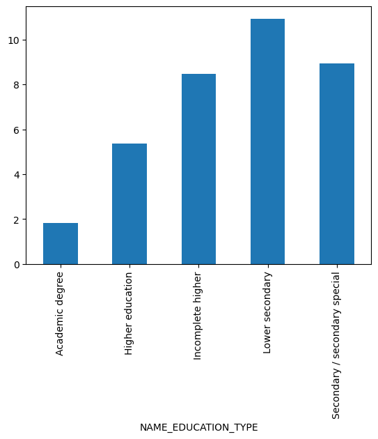

```python
((dff.groupby(['NAME_EDUCATION_TYPE'])['TARGET'].sum()/dff['NAME_EDUCATION_TYPE'].value_counts())*100).plot(kind='bar')
```

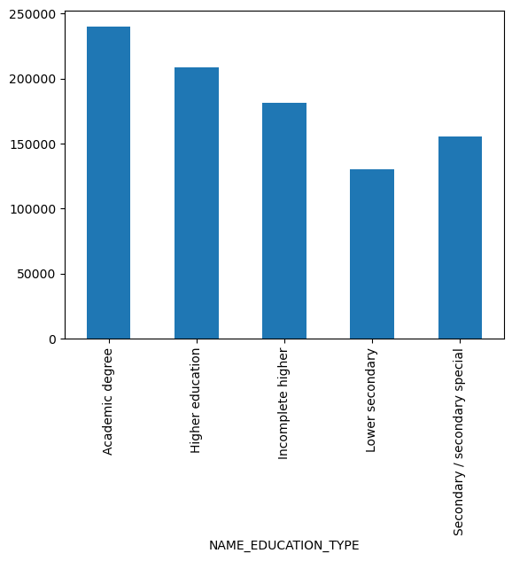

```python
dff.groupby('NAME_EDUCATION_TYPE')['AMT_INCOME_TOTAL'].mean().plot(kind='bar')
plt.show()
```

### NAME_FAMILY_STATUS

```python
dff['NAME_FAMILY_STATUS'].head()
```

```
0    Single / not married
1                 Married
2    Single / not married
3          Civil marriage
4    Single / not married
Name: NAME_FAMILY_STATUS, dtype: object
```

```python
table2=pd.crosstab(dff['NAME_FAMILY_STATUS'],dff['TARGET'])
table2
```

| TARGET NAME_FAMILY_STATUS | 0 | 1 |
| --- | --- | --- |
| Civil marriage | 26814 | 2961 |
| Married | 181582 | 14850 |
| Separated | 18150 | 1620 |
| Single / not married | 40987 | 4457 |
| Unknown | 2 | 0 |
| Widow | 15151 | 937 |

```python
observed_value=table2.values
observed_value
```

```
array([[ 26814,   2961],
       [181582,  14850],
       [ 18150,   1620],
       [ 40987,   4457],
       [     2,      0],
       [ 15151,    937]], dtype=int64)
```

HYPOTHESIS

Ho : No relation between NAME_FAMILY_STATUS and TARGET columns Ha : Relationship exist between NAME_FAMILY_STATUS and TARGET columns

```python
stats.chi2_contingency(observed= observed_value)
```

```
Chi2ContingencyResult(statistic=504.6940825563211, pvalue=7.744841561414037e-107, dof=5, expected_freq=array([[2.73712994e+04, 2.40370060e+03],
       [1.80574277e+05, 1.58577235e+04],
       [1.81739912e+04, 1.59600876e+03],
       [4.17753595e+04, 3.66864047e+03],
       [1.83854236e+00, 1.61457639e-01],
       [1.47892348e+04, 1.29876525e+03]]))
```

#### p-value is very less (of the order of -107) and hence < 0.05. Hence reject the null hypothesis.

#### Thus there is a significant relationship between NAME_FAMILY_STATUS and TARGET columns

```python
dff['NAME_FAMILY_STATUS'].isnull().sum()*100/len(dff['NAME_FAMILY_STATUS'])
```

```
0.0
```

```python
dff['NAME_FAMILY_STATUS'].value_counts()
```

```
NAME_FAMILY_STATUS
Married                 196432
Single / not married     45444
Civil marriage           29775
Separated                19770
Widow                    16088
Unknown                      2
Name: count, dtype: int64
```

```python
((dff.groupby(['NAME_FAMILY_STATUS'])['TARGET'].sum()/dff['NAME_FAMILY_STATUS'].value_counts())*100)
```

```
NAME_FAMILY_STATUS
Civil marriage          9.944584
Married                 7.559868
Separated               8.194234
Single / not married    9.807675
Unknown                 0.000000
Widow                   5.824217
dtype: float64
```

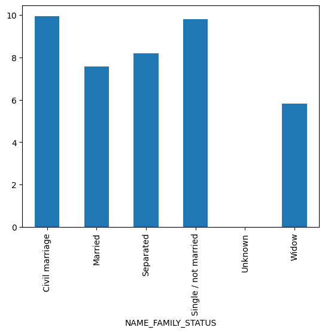

```python
((dff.groupby(['NAME_FAMILY_STATUS'])['TARGET'].sum()/dff['NAME_FAMILY_STATUS'].value_counts())*100).plot(kind='bar')
```

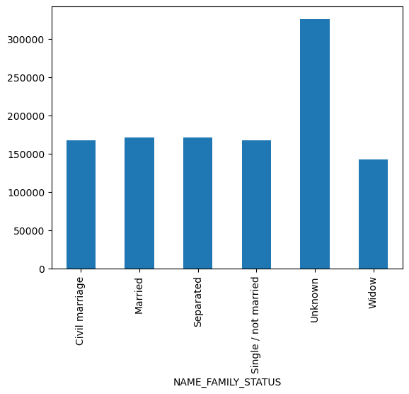

```python
dff.groupby('NAME_FAMILY_STATUS')['AMT_INCOME_TOTAL'].mean().plot(kind='bar')
plt.show()
```

### NAME_HOUSING_TYPE

```python
dff['NAME_HOUSING_TYPE'].head()
```

```
0    House / apartment
1    House / apartment
2    House / apartment
3    House / apartment
4    House / apartment
Name: NAME_HOUSING_TYPE, dtype: object
```

```python
table3=pd.crosstab(dff['NAME_HOUSING_TYPE'],dff['TARGET'])
table3
```

| TARGET NAME_HOUSING_TYPE | 0 | 1 |
| --- | --- | --- |
| Co-op apartment | 1033 | 89 |
| House / apartment | 251596 | 21272 |
| Municipal apartment | 10228 | 955 |
| Office apartment | 2445 | 172 |
| Rented apartment | 4280 | 601 |
| With parents | 13104 | 1736 |

```python
observed_value=table3.values
observed_value
```

```
array([[  1033,     89],
       [251596,  21272],
       [ 10228,    955],
       [  2445,    172],
       [  4280,    601],
       [ 13104,   1736]], dtype=int64)
```

HYPOTHESIS

Ho : No relation between NAME_HOUSING_TYPE and TARGET columns Ha : Relationship exist between NAME_HOUSING_TYPE and TARGET columns

```python
stats.chi2_contingency(observed= observed_value)
```

```
Chi2ContingencyResult(statistic=420.55618983894664, pvalue=1.0990890032617707e-88, dof=5, expected_freq=array([[1.03142226e+03, 9.05777354e+01],
       [2.50839688e+05, 2.20283115e+04],
       [1.02802096e+04, 9.02790388e+02],
       [2.40573268e+03, 2.11267321e+02],
       [4.48696263e+03, 3.94037368e+02],
       [1.36419843e+04, 1.19801568e+03]]))
```

#### p-value is very less (of the order of -88) and hence < 0.05. Hence reject the null hypothesis.

#### Thus there is a significant relationship between NAME_HOUSING_TYPE and TARGET columns

```python
dff['NAME_HOUSING_TYPE'].isnull().sum()*100/len(dff['NAME_HOUSING_TYPE'])
```

```
0.0
```

```python
dff['NAME_HOUSING_TYPE'].value_counts()
```

```
NAME_HOUSING_TYPE
House / apartment      272868
With parents            14840
Municipal apartment     11183
Rented apartment         4881
Office apartment         2617
Co-op apartment          1122
Name: count, dtype: int64
```

```python
((dff.groupby(['NAME_HOUSING_TYPE'])['TARGET'].sum()/dff['NAME_HOUSING_TYPE'].value_counts())*100)
```

```
NAME_HOUSING_TYPE
Co-op apartment         7.932264
House / apartment       7.795711
Municipal apartment     8.539748
Office apartment        6.572411
Rented apartment       12.313051
With parents           11.698113
dtype: float64
```

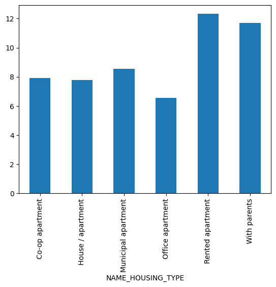

```python
((dff.groupby(['NAME_HOUSING_TYPE'])['TARGET'].sum()/dff['NAME_HOUSING_TYPE'].value_counts())*100).plot(kind='bar')
```

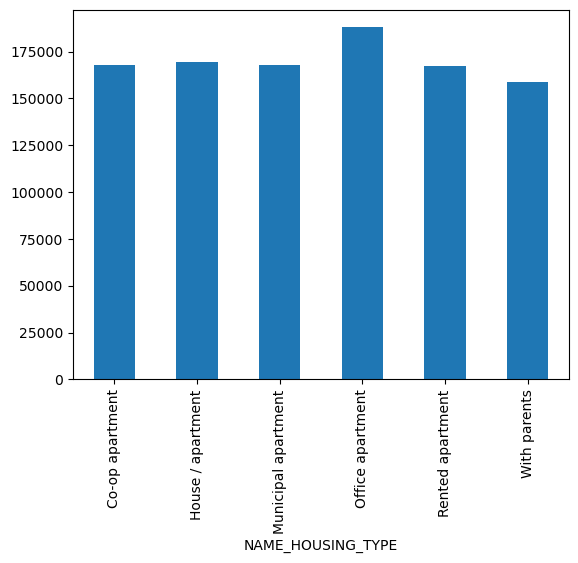

```python
dff.groupby('NAME_HOUSING_TYPE')['AMT_INCOME_TOTAL'].mean().plot(kind='bar')
plt.show()
```

### REGION_POPULATION_RELATIVE

```python
dff['REGION_POPULATION_RELATIVE'].value_counts()
```

```
REGION_POPULATION_RELATIVE
0.035792    16408
0.046220    13442
0.030755    12163
0.025164    11950
0.026392    11601
            ...
0.001417      467
0.001333      235
0.000533       39
0.000938       28
0.000290        2
Name: count, Length: 81, dtype: int64
```

```
1.4880085207077665
```

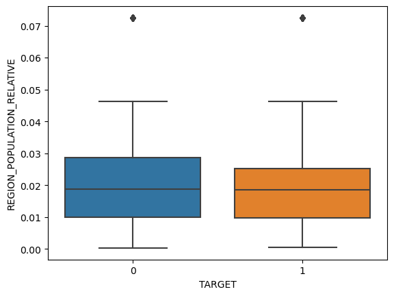

```python
sns.boxplot(y=dff['REGION_POPULATION_RELATIVE'],x=dff['TARGET'])
dff['REGION_POPULATION_RELATIVE'].skew()
```

```python
Q1 = dff['REGION_POPULATION_RELATIVE'].quantile(0.25)
Q2 = dff['REGION_POPULATION_RELATIVE'].quantile(0.5)
Q3 = dff['REGION_POPULATION_RELATIVE'].quantile(0.75)

IQR = Q3-Q1

UL = Q3+1.5*IQR
LL = Q1-1.5*IQR

print('UL',UL,'LL',LL)
```

```
UL 0.056648500000000004 LL -0.017979500000000002
```

```python
dff[(dff['REGION_POPULATION_RELATIVE'] > UL) | (dff['REGION_POPULATION_RELATIVE'] < LL)] # capping
```

|  | TARGET | NAME_CONTRACT_TYPE | CODE_GENDER | FLAG_OWN_CAR | FLAG_OWN_REALTY | CNT_CHILDREN | AMT_INCOME_TOTAL | AMT_CREDIT | AMT_ANNUITY | AMT_GOODS_PRICE | ... | AMT_REQ_CREDIT_BUREAU_WEEK | AMT_REQ_CREDIT_BUREAU_MON | AMT_REQ_CREDIT_BUREAU_QRT | AMT_REQ_CREDIT_BUREAU_YEAR | LOG_AMT_INCOME_TOTAL | FLAG_DOC_SCORE | EXT_SOURCE_AVG | LOG_AMT_CREDIT | LOG_AMT_ANNUITY | LOG_AMT_GOODS_PRICE |
| --- | --- | --- | --- | --- | --- | --- | --- | --- | --- | --- | --- | --- | --- | --- | --- | --- | --- | --- | --- | --- | --- |
| 65 | 0 | Cash loans | M | N | Y | 0 | 180000.0 | 1256400.0 | 40657.5 | 900000.0 | ... | 0.0 | 0.0 | 0.0 | 8.0 | 12.100712 | 0.000005 | 0.498730 | 14.043761 | 10.612939 | 13.710150 |
| 86 | 0 | Cash loans | F | Y | Y | 0 | 202500.0 | 343377.0 | 22072.5 | 283500.0 | ... | NaN | NaN | NaN | NaN | 12.218495 | 0.000040 | 0.238737 | 12.746584 | 10.002088 | 12.554967 |
| 105 | 0 | Cash loans | M | N | Y | 0 | 225000.0 | 448272.0 | 28647.0 | 396000.0 | ... | 0.0 | 0.0 | 1.0 | 8.0 | 12.323856 | 0.000037 | 0.421755 | 13.013155 | 10.262804 | 12.889169 |
| 111 | 0 | Cash loans | F | N | Y | 0 | 270000.0 | 891072.0 | 45625.5 | 720000.0 | ... | 0.0 | 0.0 | 0.0 | 4.0 | 12.506177 | 0.000005 | 0.499970 | 13.700181 | 10.728222 | 13.487006 |
| 188 | 0 | Cash loans | M | Y | Y | 0 | 337500.0 | 876078.0 | 49050.0 | 765000.0 | ... | 0.0 | 0.0 | 0.0 | 2.0 | 12.729321 | 0.000040 | 0.584750 | 13.683210 | 10.800595 | 13.547631 |
| ... | ... | ... | ... | ... | ... | ... | ... | ... | ... | ... | ... | ... | ... | ... | ... | ... | ... | ... | ... | ... | ... |
| 307216 | 0 | Cash loans | F | Y | Y | 0 | 225000.0 | 1827549.0 | 50386.5 | 1525500.0 | ... | NaN | NaN | NaN | NaN | 12.323856 | 0.000040 | 0.482788 | 14.418486 | 10.827479 | 14.237833 |
| 307392 | 0 | Cash loans | F | N | Y | 0 | 315000.0 | 1391130.0 | 77809.5 | 1305000.0 | ... | 0.0 | 0.0 | 0.0 | 0.0 | 12.660328 | 0.000037 | 0.420690 | 14.145627 | 11.262019 | 14.081714 |
| 307440 | 0 | Cash loans | F | N | Y | 0 | 440100.0 | 713889.0 | 45751.5 | 661500.0 | ... | NaN | NaN | NaN | NaN | 12.994757 | 0.000005 | 0.482852 | 13.478483 | 10.730980 | 13.402265 |
| 307486 | 0 | Cash loans | F | Y | Y | 1 | 292500.0 | 355536.0 | 18283.5 | 270000.0 | ... | 0.0 | 0.0 | 1.0 | 1.0 | 12.586220 | 0.000040 | 0.286932 | 12.781382 | 9.813754 | 12.506177 |
| 307498 | 0 | Cash loans | M | Y | Y | 0 | 198000.0 | 1312110.0 | 52168.5 | 1125000.0 | ... | 0.0 | 0.0 | 0.0 | 2.0 | 12.196022 | 0.000040 | 0.384292 | 14.087147 | 10.862234 | 13.933294 |

8412 rows × 80 columns

```python
dff['REGION_POPULATION_RELATIVE'] = dff['REGION_POPULATION_RELATIVE'].clip(lower = LL , upper = UL) # capping the outliers with ul and ll
```

```
0.8558735126539838
```

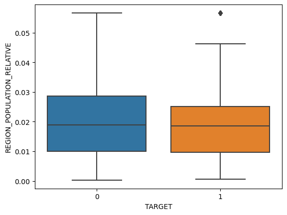

```python
sns.boxplot(y=dff['REGION_POPULATION_RELATIVE'],x=dff['TARGET'])
dff['REGION_POPULATION_RELATIVE'].skew()
```

```python
dff['REGION_POPULATION_RELATIVE'] = np.sqrt(dff['REGION_POPULATION_RELATIVE'])
print('Skewness',dff['REGION_POPULATION_RELATIVE'].skew())
```

```
Skewness 0.15071046735436883
```

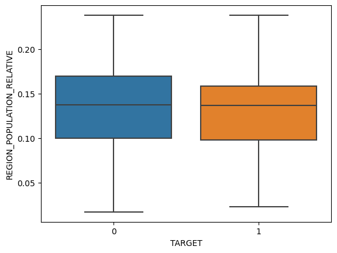

```python
sns.boxplot(y=dff['REGION_POPULATION_RELATIVE'],x=dff['TARGET'])
```

HYPOTHESIS

Ho : No relation between REGION_POPULATION_RELATIVE and TARGET columns Ha : Relationship exist between REGION_POPULATION_RELATIVE and TARGET columns

```python
stats.shapiro(dff['REGION_POPULATION_RELATIVE'])
```

```
ShapiroResult(statistic=0.980702165246496, pvalue=6.206605481357661e-90)
```

```python
pg.homoscedasticity(dff, dv='TARGET', group='REGION_POPULATION_RELATIVE')
```

|  | W | pval | equal_var |
| --- | --- | --- | --- |
| levene | 21.529009 | 1.358018e-305 | False |

```python
dff['TARGET'].value_counts()
```

```
TARGET
0    282686
1     24825
Name: count, dtype: int64
```

```python
default=dff[dff['TARGET']==1]['REGION_POPULATION_RELATIVE']
nondefault=dff[dff['TARGET']==0]['REGION_POPULATION_RELATIVE']
```

```python
len(default)
```

```
24825
```

```python
d1=default.sample(frac=1,random_state=42).reset_index(drop=True)
```

```python
nd1=np.random.choice(nondefault,size=24825,replace=False)
```

```python
stats.mannwhitneyu(d1,nd1)
```

```
MannwhitneyuResult(statistic=287208551.0, pvalue=2.7906393006699018e-39)
```

#### Thus there is a significant relationship between REGION_POPULATION_RELATIVE and TARGET columns

### DAYS_BIRTH

```python
dff['DAYS_BIRTH'].value_counts()
```

```
DAYS_BIRTH
-13749    43
-13481    42
-18248    41
-10020    41
-15771    40
          ..
-24898     1
-24868     1
-8017      1
-25098     1
-25061     1
Name: count, Length: 17460, dtype: int64
```

```
-0.11567331170166129
```

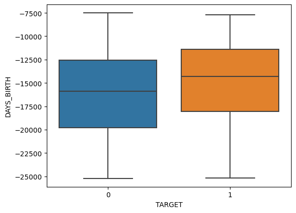

```python
sns.boxplot(y=dff['DAYS_BIRTH'],x=dff['TARGET'])
dff['DAYS_BIRTH'].skew()
```

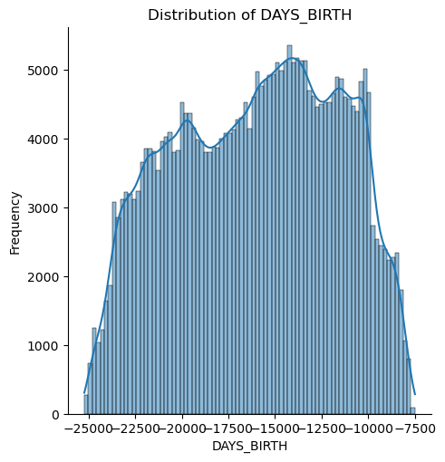

```python
sns.displot(dff['DAYS_BIRTH'], kde=True)
plt.title('Distribution of DAYS_BIRTH')
plt.xlabel('DAYS_BIRTH')
plt.ylabel('Frequency')
plt.show()
```

```python
stats.shapiro(dff['DAYS_BIRTH'])
```

```
ShapiroResult(statistic=0.9696564518865336, pvalue=1.7093576641658382e-101)
```

```python
pg.homoscedasticity(dff, dv='TARGET', group='DAYS_BIRTH')
```

|  | W | pval | equal_var |
| --- | --- | --- | --- |
| levene | 1.094171 | 6.194565e-17 | False |

```python
default=dff[dff['TARGET']==1]['DAYS_BIRTH']
nondefault=dff[dff['TARGET']==0]['DAYS_BIRTH']
```

```python
len(default)
```

```
24825
```

```python
d1=default.sample(frac=1,random_state=42).reset_index(drop=True)
```

```python
nd1=np.random.choice(nondefault,size=24825,replace=False)
```

HYPOTHESIS Ho : No relation between DAYS_BIRTH and TARGET columns Ha : Relationship exist between DAYS_BIRTH and TARGET columns

```python
stats.mannwhitneyu(d1,nd1)
```

```
MannwhitneyuResult(statistic=358234586.0, pvalue=5.0656729123998523e-216)
```

#### Thus there is a significant relationship between DAYS_BIRTH and TARGET columns

### DAYS_EMPLOYED

```python
dff['DAYS_EMPLOYED'].value_counts()
```

```
DAYS_EMPLOYED
 365243    55374
-200         156
-224         152
-230         151
-199         151
           ...
-13961         1
-11827         1
-10176         1
-9459          1
-8694          1
Name: count, Length: 12574, dtype: int64
```

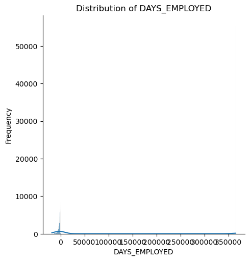

```
1.6643461980685423
```

```python
sns.displot(dff['DAYS_EMPLOYED'], kde=True)
plt.title('Distribution of DAYS_EMPLOYED')
plt.xlabel('DAYS_EMPLOYED')
plt.ylabel('Frequency')
plt.show()
dff['DAYS_EMPLOYED'].skew()
```

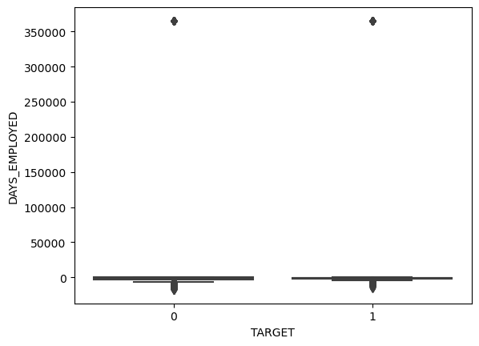

```python
sns.boxplot(y=dff['DAYS_EMPLOYED'],x=dff['TARGET'])
```

```python
Q1 = dff['DAYS_EMPLOYED'].quantile(0.25)
Q2 = dff['DAYS_EMPLOYED'].quantile(0.5)
Q3 = dff['DAYS_EMPLOYED'].quantile(0.75)

IQR = Q3-Q1

UL = Q3+1.5*IQR
LL = Q1-IQR


# a['DAYS_EMP_NEW'] = a['DAYS_EMPLOYED'][(a['DAYS_EMPLOYED'] < UL) & (a['DAYS_EMPLOYED'] > LL)]
```

```python
dff['DAYS_EMPLOYED'] = dff['DAYS_EMPLOYED'].clip(lower = LL , upper = UL) # capping the outliers with ul and ll
```

```
0.4087218784202031
```

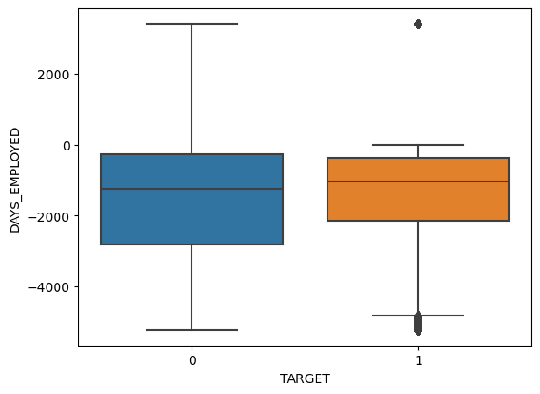

```python
sns.boxplot(y=dff['DAYS_EMPLOYED'],x=dff['TARGET'])
dff['DAYS_EMPLOYED'].skew()
```

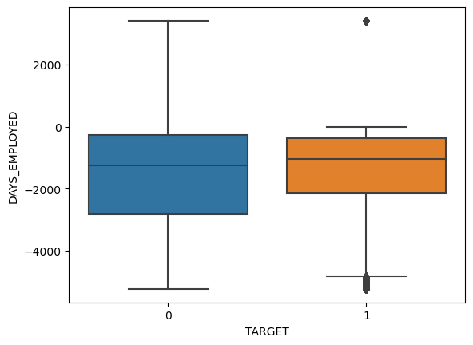

```python
sns.boxplot(y=dff['DAYS_EMPLOYED'],x=dff['TARGET'])
```

HYPOTHESIS Ho : No relation between DAYS_EMPLOYED and TARGET columns Ha : Relationship exist between DAYS_EMPLOYED and TARGET columns

```python
stats.shapiro(dff['DAYS_EMPLOYED'])
```

```
ShapiroResult(statistic=0.9057415692539235, pvalue=1.434362846341812e-133)
```

```python
pg.homoscedasticity(dff, dv='TARGET', group='DAYS_EMPLOYED')
```

|  | W | pval | equal_var |
| --- | --- | --- | --- |
| levene | 1.471183 | 4.545046e-97 | False |

```python
default=dff[dff['TARGET']==1]['DAYS_EMPLOYED']
nondefault=dff[dff['TARGET']==0]['DAYS_EMPLOYED']
```

```python
len(default)
```

```
24825
```

```python
d1=default.sample(frac=1,random_state=42).reset_index(drop=True)
```

```python
nd1=np.random.choice(nondefault,size=24825,replace=False)
```

```python
stats.mannwhitneyu(d1,nd1)
```

```
MannwhitneyuResult(statistic=323470264.0, pvalue=6.653804434526713e-22)
```

#### Thus there is a significant relationship between DAYS_EMPLOYED and TARGET columns

## DAYS_REGISTRATION - How many days before the application did client change his registration time only relative to the application

```python
dff['DAYS_REGISTRATION'].value_counts()
```

```
DAYS_REGISTRATION
-1.0        113
-7.0         98
-6.0         96
-4.0         92
-2.0         92
           ...
-15581.0      1
-15031.0      1
-14804.0      1
-15008.0      1
-14798.0      1
Name: count, Length: 15688, dtype: int64
```

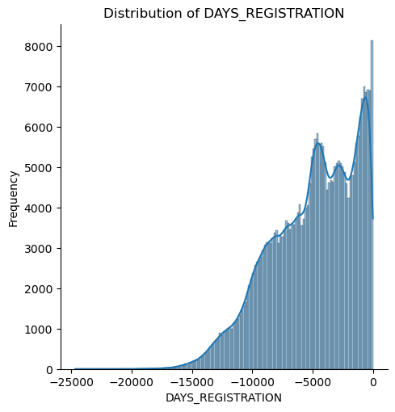

```
-0.590871615735003
```

```python
sns.displot(dff['DAYS_REGISTRATION'], kde=True)
plt.title('Distribution of DAYS_REGISTRATION')
plt.xlabel('DAYS_REGISTRATION')
plt.ylabel('Frequency')
plt.show()
dff['DAYS_REGISTRATION'].skew()
```

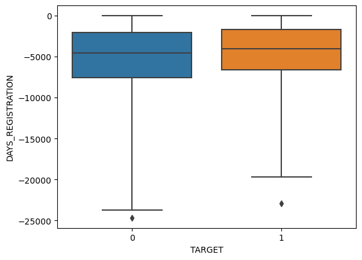

```python
sns.boxplot(y=dff['DAYS_REGISTRATION'],x=dff['TARGET'] , whis = 3)
```

```python
# Outlier treatment

Q1 = dff['DAYS_REGISTRATION'].quantile(0.25)
Q2 = dff['DAYS_REGISTRATION'].quantile(0.5)
Q3 = dff['DAYS_REGISTRATION'].quantile(0.75)

IQR = Q3-Q1

UL = Q3+3*IQR
LL = Q1-3*IQR

# a['DAYS_REG_NEW'] = a['DAYS_REGISTRATION'][(a['DAYS_REGISTRATION'] < UL) & (a['DAYS_REGISTRATION'] > LL)]
```

```python
dff['DAYS_REGISTRATION'] = dff['DAYS_REGISTRATION'].clip(lower = LL , upper = UL) # capping the outliers with ul and ll
```

```
-0.590815681485009
```

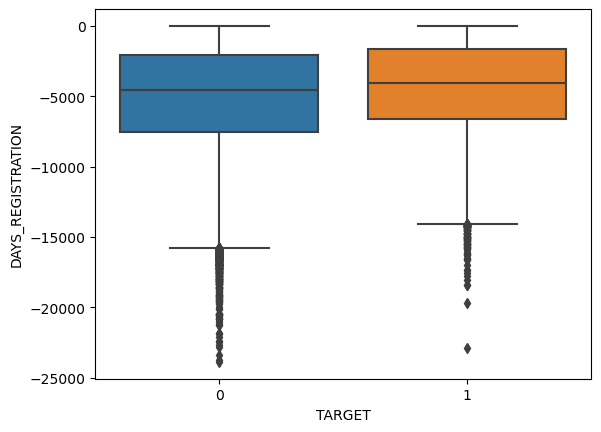

```python
sns.boxplot(y=dff['DAYS_REGISTRATION'],x=dff['TARGET'])
dff['DAYS_REGISTRATION'].skew()
```

```python
# As the data is left skewed we go for Transformation
dff['DAYS_REGISTRATION'] = np.sqrt(abs(dff['DAYS_REGISTRATION']))
dff['DAYS_REGISTRATION'].skew()
```

```
-0.1796036530044704
```

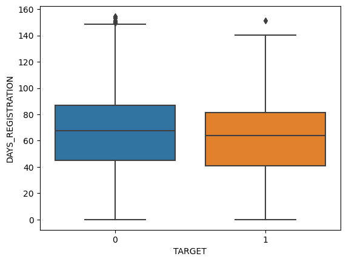

```python
sns.boxplot(y=dff['DAYS_REGISTRATION'],x=dff['TARGET'])
```

```python
stats.shapiro(dff['DAYS_REGISTRATION'])
```

```
ShapiroResult(statistic=0.9850000991565856, pvalue=8.309913644827373e-84)
```

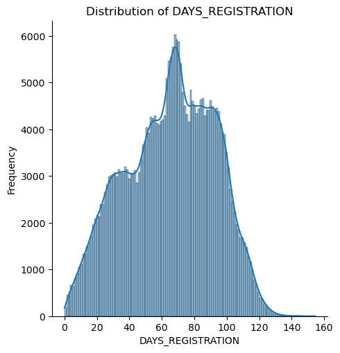

```python
sns.displot(dff['DAYS_REGISTRATION'], kde=True)
plt.title('Distribution of DAYS_REGISTRATION')
plt.xlabel('DAYS_REGISTRATION')
plt.ylabel('Frequency')
plt.show()
```

```python
pg.homoscedasticity(dff, dv='TARGET', group='DAYS_REGISTRATION')
```

|  | W | pval | equal_var |
| --- | --- | --- | --- |
| levene | 0.877153 | 1.0 | True |

```python
default=dff[dff['TARGET']==1]['DAYS_REGISTRATION']
nondefault=dff[dff['TARGET']==0]['DAYS_REGISTRATION']
```

```python
len(default)
```

```
24825
```

```python
d1=np.array(default.sample(frac=1,random_state=42).reset_index(drop=True))
```

```python
nd1=np.random.choice(nondefault,size=24825,replace=False)
```

```python
d1.shape
```

```
(24825,)
```

```python
stats.mannwhitneyu(d1,nd1)
```

```
MannwhitneyuResult(statistic=281038472.5, pvalue=1.3207267036854535e-64)
```

#### Thus there is a significant relationship between DAYS_REGISTRATION and TARGET columns

### DAYS_ID_PUBLISH

## How many days before the application did client change the identity document with which he applied for the loan

```python
dff['DAYS_ID_PUBLISH'].isnull().sum()
```

```
0
```

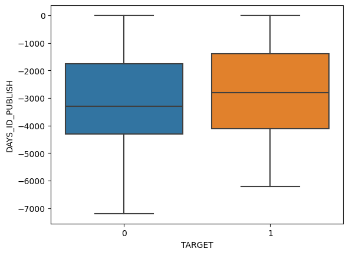

```python
sns.boxplot(y=dff['DAYS_ID_PUBLISH'],x=dff['TARGET'])
plt.show()
```

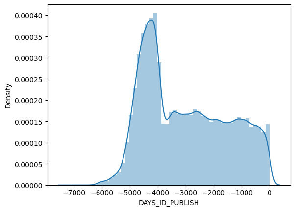

```python
sns.distplot(dff['DAYS_ID_PUBLISH'])
```

```python
dff['DAYS_ID_PUBLISH'].skew()
```

```
0.3493274932029977
```

HYPOTHESIS

Ho : No relation between DAYS_ID_PUBLISH and TARGET columns Ha : Relationship exist between DAYS_ID_PUBLISH and TARGET columns

```python
Target1=dff[dff['TARGET']==1]['DAYS_ID_PUBLISH']
```

```python
Target1
```

```
0        -2120
26       -1827
40       -1029
42       -4409
81       -4199
          ...
307448   -2580
307475   -4704
307481   -3832
307489      -9
307509    -931
Name: DAYS_ID_PUBLISH, Length: 24825, dtype: int64
```

```python
len(Target1)
```

```
24825
```

```python
Target2=dff[dff['TARGET']==0]['DAYS_ID_PUBLISH']
```

```python
Target2
```

```
1         -291
2        -2531
3        -2437
4        -3458
5         -477
          ...
307505   -2357
307506   -1982
307507   -4090
307508   -5150
307510    -410
Name: DAYS_ID_PUBLISH, Length: 282686, dtype: int64
```

```python
sample=np.random.choice(Target2,size=24825,replace=True)
```

```python
len(sample)
```

```
24825
```

```python
stats.levene(Target1.values,sample)
```

```
LeveneResult(statistic=9.893942445911222, pvalue=0.0016592155298397)
```

```python
stats.shapiro(Target1.values)
```

```
ShapiroResult(statistic=0.9507111098013546, pvalue=3.477429138347774e-66)
```

```python
stats.shapiro(sample)
```

```
ShapiroResult(statistic=0.9392089152433044, pvalue=1.5212070707369342e-70)
```

```python
stats.mannwhitneyu(Target1.values,sample)
```

```
MannwhitneyuResult(statistic=342705164.5, pvalue=6.669119680957791e-104)
```

#### Thus there is a significant relationship between DAYS_ID_PUBLISH and TARGET columns

# d=dff[dff['TARGET']==1]

```python
d=dff[dff['TARGET']==1]
```

### FLAG_MOBIL

```python
dff['FLAG_MOBIL'].isnull().sum()
```

```
0
```

```python
dff['FLAG_MOBIL'].value_counts()
```

```
FLAG_MOBIL
1    307510
0         1
Name: count, dtype: int64
```

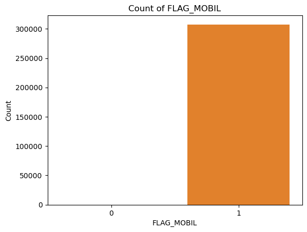

```python
sns.countplot(data=dff, x='FLAG_MOBIL')
plt.title('Count of FLAG_MOBIL')
plt.xlabel('FLAG_MOBIL')
plt.ylabel('Count')
plt.show()
```

```python
dff['FLAG_MOBIL'].value_counts() # can remove this column as no variation in data
```

```
FLAG_MOBIL
1    307510
0         1
Name: count, dtype: int64
```

```python
d['FLAG_MOBIL'].value_counts()
```

```
FLAG_MOBIL
1    24825
Name: count, dtype: int64
```

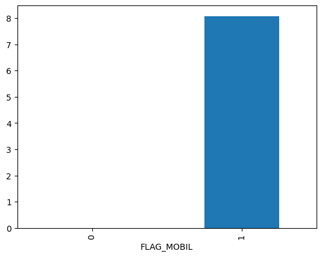

```python
(d['FLAG_MOBIL'].value_counts()*100/dff['FLAG_MOBIL'].value_counts()).plot(kind='bar')
```

```python
table1=pd.crosstab(dff['FLAG_MOBIL'],dff['TARGET'])
```

```python
observed_values=table1.values
```

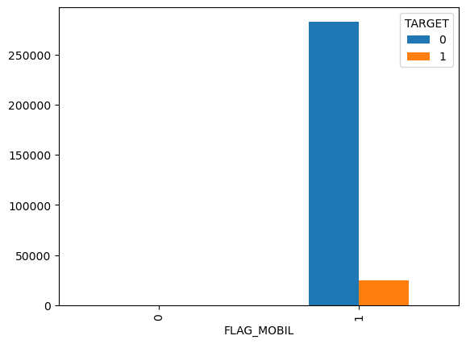

```python
table1=pd.crosstab(dff['FLAG_MOBIL'],dff['TARGET']).plot(kind='bar')
```

HYPOTHESIS

Ho : No relation between FLAG_MOBIL and TARGET columns Ha : Relationship exist between FLAG_MOBIL and TARGET columns

```python
stats.chi2_contingency(observed_values)
```

```
Chi2ContingencyResult(statistic=0.0, pvalue=1.0, dof=1, expected_freq=array([[9.19271181e-01, 8.07288195e-02],
       [2.82685081e+05, 2.48249193e+04]]))
```

## from hypothesis test we can infere that we accept null hypothesis which say there dooesnt exist a realtionship

#### p-value 1.0 > 0.05. Hence failed to reject the null hypothesis.

#### Thus there is no significant relationship between FLAG_MOBIL and TARGET columns

### FLAG_EMP_PHONE

```python
dff['FLAG_EMP_PHONE'].isnull().sum()
```

```
0
```

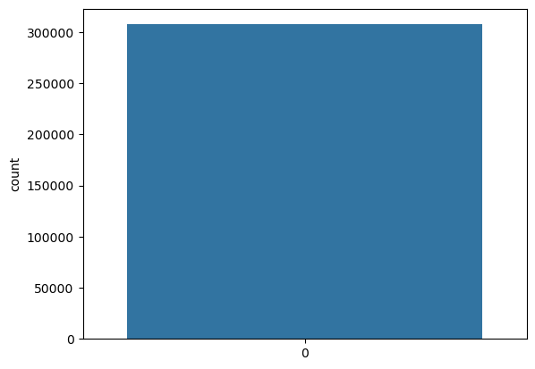

```python
sns.countplot(dff['FLAG_EMP_PHONE'])
```

```python
dff['FLAG_EMP_PHONE'].value_counts()
```

```
FLAG_EMP_PHONE
1    252125
0     55386
Name: count, dtype: int64
```

```python
d['FLAG_EMP_PHONE'].value_counts()
```

```
FLAG_EMP_PHONE
1    21834
0     2991
Name: count, dtype: int64
```

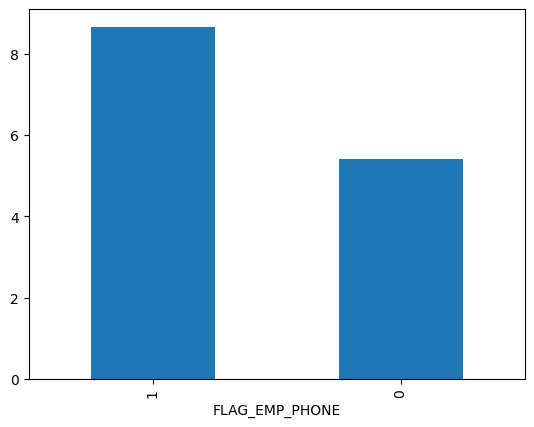

```python
(d['FLAG_EMP_PHONE'].value_counts()*100/dff['FLAG_EMP_PHONE'].value_counts()).plot(kind='bar')
```

```python
table2=pd.crosstab(dff['FLAG_EMP_PHONE'],dff['TARGET'])
```

```python
observed_values2=table2.values
```

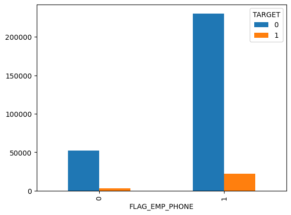

```python
table2=pd.crosstab(dff['FLAG_EMP_PHONE'],dff['TARGET']).plot(kind='bar')
```

HYPOTHESIS

Ho : No relation between FLAG_EMP_PHONE and TARGET columns Ha : Relationship exist between FLAG_EMP_PHONE and TARGET columns

```python
stats.chi2_contingency(observed_values2)
```

```
Chi2ContingencyResult(statistic=649.75118051112, pvalue=2.5306059279614537e-143, dof=1, expected_freq=array([[ 50914.75360556,   4471.24639444],
       [231771.24639444,  20353.75360556]]))
```

#### p-value is very less (of the order of -143) and hence < 0.05. Hence reject the null hypothesis.

#### Thus there is a significant relationship between FLAG_EMP_PHONE and TARGET columns

### FLAG_CONT_MOBILE

```python
dff['FLAG_CONT_MOBILE'].isnull().sum()
```

```
0
```

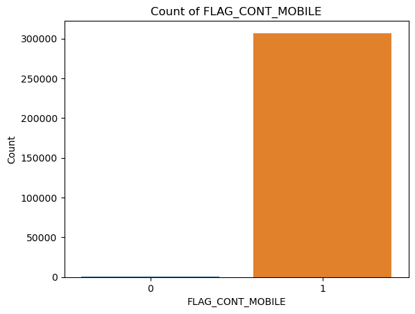

```python
sns.countplot(data=dff, x='FLAG_CONT_MOBILE')
plt.title('Count of FLAG_CONT_MOBILE')
plt.xlabel('FLAG_CONT_MOBILE')
plt.ylabel('Count')
plt.show()
```

```python
dff['FLAG_CONT_MOBILE'].value_counts() # even this column is highly imbalanced
```

```
FLAG_CONT_MOBILE
1    306937
0       574
Name: count, dtype: int64
```

```python
d['FLAG_CONT_MOBILE'].value_counts()
```

```
FLAG_CONT_MOBILE
1    24780
0       45
Name: count, dtype: int64
```

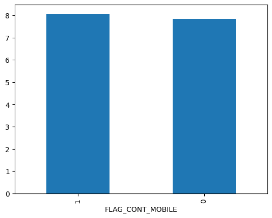

```python
(d['FLAG_CONT_MOBILE'].value_counts()*100/dff['FLAG_CONT_MOBILE'].value_counts()).plot(kind='bar')
```

```python
table4=pd.crosstab(dff['FLAG_CONT_MOBILE'],dff['TARGET'])
```

```python
observed_values4=table4.values
```

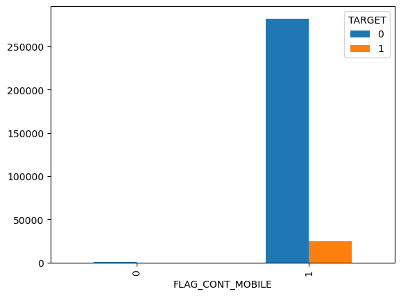

```python
table4=pd.crosstab(dff['FLAG_CONT_MOBILE'],dff['TARGET']).plot(kind='bar')
```

HYPOTHESIS

Ho : No relation between FLAG_CONT_MOBILE and TARGET columns Ha : Relationship exist between FLAG_CONT_MOBILE and TARGET columns

```python
stats.chi2_contingency(observed_values4)
```

```
Chi2ContingencyResult(statistic=0.016529895300634423, pvalue=0.8976989816319643, dof=1, expected_freq=array([[5.27661658e+02, 4.63383424e+01],
       [2.82158338e+05, 2.47786617e+04]]))
```

#### p-value 0.9 > 0.05. Hence failed to reject the null hypothesis.

#### Thus there is no significant relationship between FLAG_CONT_MOBILE and TARGET columns

### FLAG_PHONE

```python
dff['FLAG_PHONE'].isnull().sum()
```

```
0
```

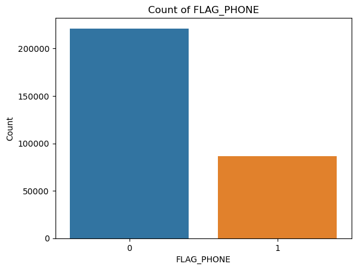

```python
sns.countplot(data=dff, x='FLAG_PHONE')
plt.title('Count of FLAG_PHONE')
plt.xlabel('FLAG_PHONE')
plt.ylabel('Count')
plt.show()
```

```python
dff['FLAG_PHONE'].value_counts()
```

```
FLAG_PHONE
0    221080
1     86431
Name: count, dtype: int64
```

```python
d['FLAG_PHONE'].value_counts()
```

```
FLAG_PHONE
0    18744
1     6081
Name: count, dtype: int64
```

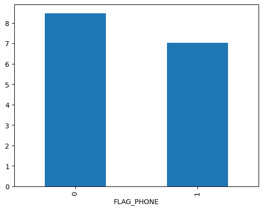

```python
(d['FLAG_PHONE'].value_counts()*100/dff['FLAG_PHONE'].value_counts()).plot(kind='bar')
```

```python
table5=pd.crosstab(dff['FLAG_PHONE'],dff['TARGET'])
```

```python
observed_values5=table5.values
```

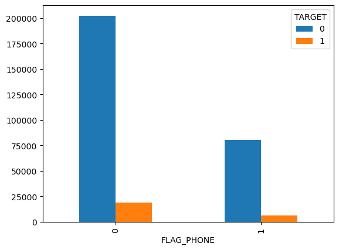

```python
table5=pd.crosstab(dff['FLAG_PHONE'],dff['TARGET']).plot(kind='bar')
```

HYPOTHESIS

Ho : No relation between FLAG_PHONE and TARGET columns Ha : Relationship exist between FLAG_PHONE and TARGET columns

```python
stats.chi2_contingency(observed_values5)
```

```
Chi2ContingencyResult(statistic=174.08400398216486, pvalue=9.489418049556951e-40, dof=1, expected_freq=array([[203232.47259448,  17847.52740552],
       [ 79453.52740552,   6977.47259448]]))
```

#### p-value is very less (of the order of -40) and hence < 0.05. Hence reject the null hypothesis.

#### Thus there is a significant relationship between FLAG_PHONE and TARGET columns

## FLAG_EMAIL

```python
dff['FLAG_EMAIL'].isnull().sum()
```

```
0
```

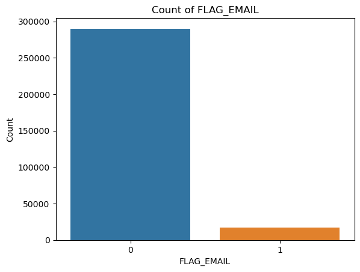

```python
sns.countplot(data=dff, x='FLAG_EMAIL')
plt.title('Count of FLAG_EMAIL')
plt.xlabel('FLAG_EMAIL')
plt.ylabel('Count')
plt.show()
```

```python
dff['FLAG_EMAIL'].value_counts()
```

```
FLAG_EMAIL
0    290069
1     17442
Name: count, dtype: int64
```

```python
d['FLAG_EMAIL'].value_counts()
```

```
FLAG_EMAIL
0    23451
1     1374
Name: count, dtype: int64
```

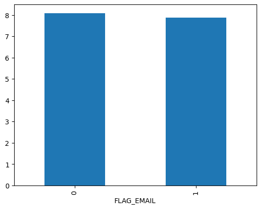

```python
(d['FLAG_EMAIL'].value_counts()*100/dff['FLAG_EMAIL'].value_counts()).plot(kind='bar')
```

```python
table6=pd.crosstab(dff['FLAG_EMAIL'],dff['TARGET'])
```

```python
observed_values6=table6.values
```

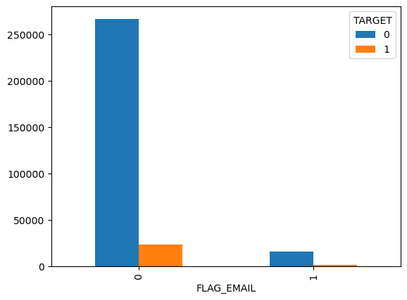

```python
table6=pd.crosstab(dff['FLAG_EMAIL'],dff['TARGET']).plot(kind='bar')
```

HYPOTHESIS

Ho : No relation between FLAG_EMAIL and TARGET columns Ha : Relationship exist between FLAG_EMAIL and TARGET columns

```python
stats.chi2_contingency(observed_values6)
```

```
Chi2ContingencyResult(statistic=0.92309632556523, pvalue=0.3366632895181666, dof=1, expected_freq=array([[266652.07206897,  23416.92793103],
       [ 16033.92793103,   1408.07206897]]))
```

#### p-value 0.3 > 0.05. Hence failed to reject the null hypothesis.

#### Thus there is no significant relationship between FLAG_EMAIL and TARGET columns

### REGION_RATING_CLIENT_W_CITY

```python
reg_w=pd.crosstab(dff['TARGET'],dff['REGION_RATING_CLIENT_W_CITY'])
```

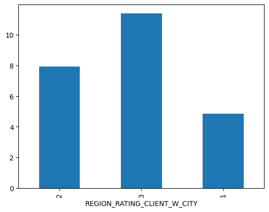

```python
(d['REGION_RATING_CLIENT_W_CITY'].value_counts()*100/(dff['REGION_RATING_CLIENT_W_CITY'].value_counts())).plot(kind='bar')
```

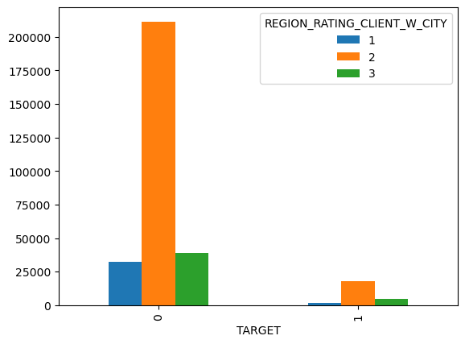

```python
reg_w.plot(kind='bar')
```

HYPOTHESIS

Ho : No relation between REGION_RATING_CLIENT_W_CITY and TARGET columns Ha : Relationship exist between REGION_RATING_CLIENT_W_CITY and TARGET columns

```python
stats.chi2_contingency(reg_w)
```

```
Chi2ContingencyResult(statistic=1143.446337622771, pvalue=5.05571529094165e-249, dof=2, expected_freq=array([[ 31408.73842562, 210958.02759576,  40319.23397862],
       [  2758.26157438,  18525.97240424,   3540.76602138]]))
```

#### p-value is very less (of the order of -249) and hence < 0.05. Hence reject the null hypothesis.

#### Thus there is a significant relationship between REGION_RATING_CLIENT_W_CITY and TARGET columns

### CNT_FAM_MEMBERS

```python
CNT_FAM_tar=pd.crosstab(dff['TARGET'],dff['CNT_FAM_MEMBERS'])
```

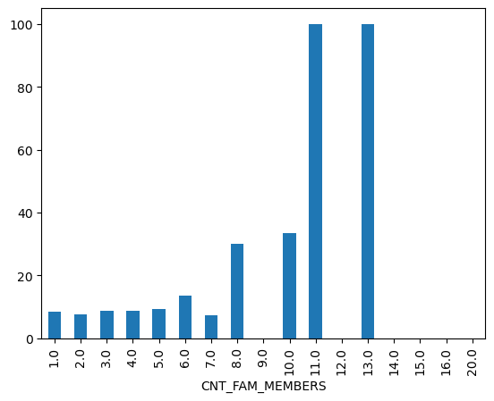

```python
(d['CNT_FAM_MEMBERS'].value_counts()*100/(dff['CNT_FAM_MEMBERS'].value_counts())).plot(kind='bar')
```

```python
lis2=[]
for i in dff['CNT_FAM_MEMBERS']:
    if i<=4:
        lis2.append('small family')
    elif i>4:
        lis2.append('large family')

lis3=pd.Series(lis2)
dff['CNT_FAM_MEMBERS_']=pd.DataFrame(lis3)
dff['CNT_FAM_MEMBERS_'].value_counts()
```

```
CNT_FAM_MEMBERS_
small family    303502
large family      4007
Name: count, dtype: int64
```

```python
CNT_FAM_tar
```

| CNT_FAM_MEMBERS TARGET | 1.0 | 2.0 | 3.0 | 4.0 | 5.0 | 6.0 | 7.0 | 8.0 | 9.0 | 10.0 | 11.0 | 12.0 | 13.0 | 14.0 | 15.0 | 16.0 | 20.0 |
| --- | --- | --- | --- | --- | --- | --- | --- | --- | --- | --- | --- | --- | --- | --- | --- | --- | --- |
| 0 | 62172 | 146348 | 47993 | 22561 | 3151 | 353 | 75 | 14 | 6 | 2 | 0 | 2 | 0 | 2 | 1 | 2 | 2 |
| 1 | 5675 | 12009 | 4608 | 2136 | 327 | 55 | 6 | 6 | 0 | 1 | 1 | 0 | 1 | 0 | 0 | 0 | 0 |

HYPOTHESIS

Ho : No relation between CNT_FAM_MEMBERS and TARGET columns Ha : Relationship exist between CNT_FAM_MEMBERS and TARGET columns

```python
stats.chi2_contingency(CNT_FAM_tar)
```

```
Chi2ContingencyResult(statistic=167.4373228270056, pvalue=2.730183369578879e-27, dof=16, expected_freq=array([[6.23697562e+04, 1.45572943e+05, 4.83545557e+04, 2.27032274e+04,
        3.19722334e+03, 3.75062427e+02, 7.44609231e+01, 1.83854131e+01,
        5.51562393e+00, 2.75781197e+00, 9.19270655e-01, 1.83854131e+00,
        9.19270655e-01, 1.83854131e+00, 9.19270655e-01, 1.83854131e+00,
        1.83854131e+00],
       [5.47724384e+03, 1.27840568e+04, 4.24644425e+03, 1.99377262e+03,
        2.80776660e+02, 3.29375726e+01, 6.53907691e+00, 1.61458689e+00,
        4.84376067e-01, 2.42188034e-01, 8.07293445e-02, 1.61458689e-01,
        8.07293445e-02, 1.61458689e-01, 8.07293445e-02, 1.61458689e-01,
        1.61458689e-01]]))
```

#### p-value is very less (of the order of -27) and hence < 0.05. Hence reject the null hypothesis.

#### Thus there is a significant relationship between CNT_FAM_MEMBERS and TARGET columns

### REGION_RATING_CLIENT

```python
Region_r=pd.crosstab(dff['TARGET'],dff['REGION_RATING_CLIENT'])
```

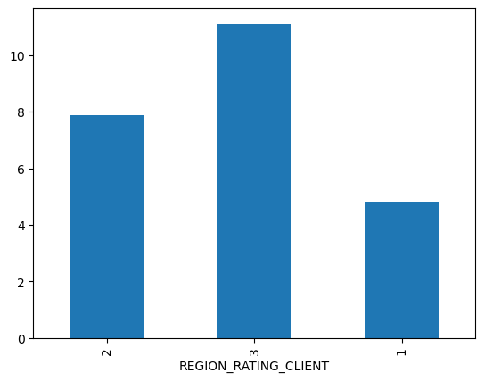

```python
(d['REGION_RATING_CLIENT'].value_counts()*100/(dff['REGION_RATING_CLIENT'].value_counts())).plot(kind='bar')
```

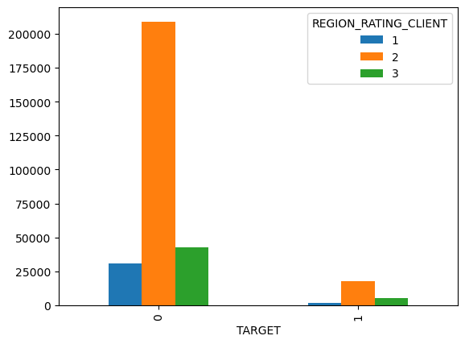

```python
Region_r.plot(kind='bar')
```

HYPOTHESIS

Ho : No relation between REGION_RATING_CLIENT and TARGET columns Ha : Relationship exist between REGION_RATING_CLIENT and TARGET columns

```python
stats.chi2_contingency(Region_r)
```

```
Chi2ContingencyResult(statistic=1067.1926919578827, pvalue=1.8283164955910817e-232, dof=2, expected_freq=array([[ 29597.77419995, 208659.8496444 ,  44428.37615565],
       [  2599.22580005,  18324.1503556 ,   3901.62384435]]))
```

#### p-value is very less (of the order of -232) and hence < 0.05. Hence reject the null hypothesis.

#### Thus there is a significant relationship between REGION_RATING_CLIENT and TARGET columns

### WEEKDAY_APPR_PROCESS_START

```python
WEEKDAY_Tar=pd.crosstab(dff['TARGET'],dff['WEEKDAY_APPR_PROCESS_START'])
```

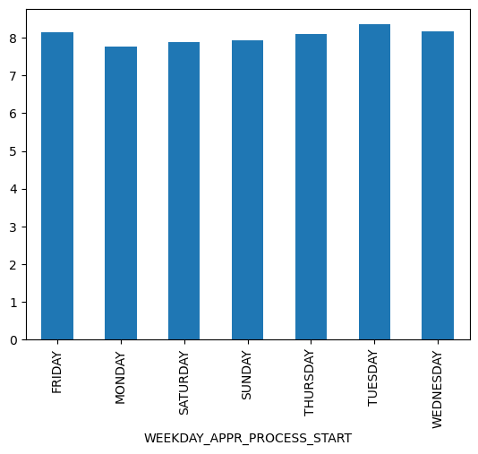

```python
(d['WEEKDAY_APPR_PROCESS_START'].value_counts()*100/(dff['WEEKDAY_APPR_PROCESS_START'].value_counts())).plot(kind='bar')
```

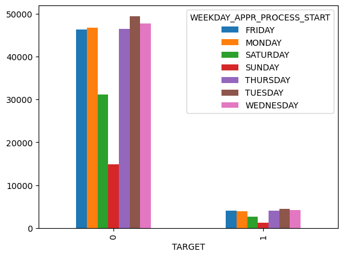

```python
WEEKDAY_Tar.plot(kind='bar')
```

HYPOTHESIS

Ho : No relation between WEEKDAY_APPR_PROCESS_START and TARGET columns Ha : Relationship exist between WEEKDAY_APPR_PROCESS_START and TARGET columns

```python
stats.chi2_contingency(WEEKDAY_Tar)
```

```
Chi2ContingencyResult(statistic=15.38755691304465, pvalue=0.017447369313895057, dof=6, expected_freq=array([[46274.27268618, 46619.91865006, 31119.16800375, 14874.72697237,
        46506.84829486, 49549.63590246, 47741.42949033],
       [ 4063.72731382,  4094.08134994,  2732.83199625,  1306.27302763,
         4084.15170514,  4351.36409754,  4192.57050967]]))
```

#### p-value 0.02 < 0.05. Hence reject the null hypothesis.

#### Thus there is a significant relationship between WEEKDAY_APPR_PROCESS_START and TARGET columns

## HOUR_APPR_PROCESS_START

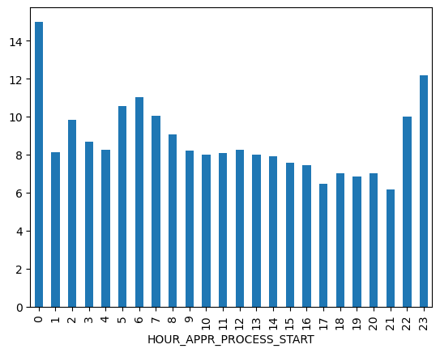

```python
(d['HOUR_APPR_PROCESS_START'].value_counts()*100/(dff['HOUR_APPR_PROCESS_START'].value_counts())).plot(kind='bar')
```

```python
lis=[]
for i in dff['HOUR_APPR_PROCESS_START']:
    if i<=8:
        lis.append('shift1')
    elif 8<i<=16:
        lis.append('shift2')
    elif 16<i<=24:
        lis.append('shift3')

lis1=pd.Series(lis)
dff['HOUR_APPR_PROCESS_START']=lis1
dff['HOUR_APPR_PROCESS_START'].value_counts()
```

```
HOUR_APPR_PROCESS_START
shift2    240433
shift1     37489
shift3     29589
Name: count, dtype: int64
```

```python
HOUR_Tar=pd.crosstab(dff['TARGET'],dff['HOUR_APPR_PROCESS_START'])
```

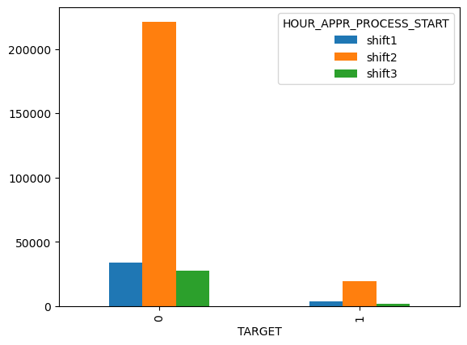

```python
HOUR_Tar.plot(kind ='bar')
```

HYPOTHESIS

Ho : No relation between HOUR_APPR_PROCESS_START and TARGET columns Ha : Relationship exist between HOUR_APPR_PROCESS_START and TARGET columns

```python
stats.chi2_contingency(HOUR_Tar)
```

```
Chi2ContingencyResult(statistic=210.00383531309876, pvalue=2.5017653462526253e-46, dof=2, expected_freq=array([[ 34462.55728738, 221023.12775153,  27200.31496109],
       [  3026.44271262,  19409.87224847,   2388.68503891]]))
```

### REG_REGION_NOT_LIVE_REGION

```python
dff[dff['REG_REGION_NOT_LIVE_REGION'].isnull()==True]
```

|  | TARGET | NAME_CONTRACT_TYPE | CODE_GENDER | FLAG_OWN_CAR | FLAG_OWN_REALTY | CNT_CHILDREN | AMT_INCOME_TOTAL | AMT_CREDIT | AMT_ANNUITY | AMT_GOODS_PRICE | ... | AMT_REQ_CREDIT_BUREAU_MON | AMT_REQ_CREDIT_BUREAU_QRT | AMT_REQ_CREDIT_BUREAU_YEAR | LOG_AMT_INCOME_TOTAL | FLAG_DOC_SCORE | EXT_SOURCE_AVG | LOG_AMT_CREDIT | LOG_AMT_ANNUITY | LOG_AMT_GOODS_PRICE | CNT_FAM_MEMBERS_ |
| --- | --- | --- | --- | --- | --- | --- | --- | --- | --- | --- | --- | --- | --- | --- | --- | --- | --- | --- | --- | --- | --- |

0 rows × 81 columns

```python
dff['REG_REGION_NOT_LIVE_REGION'].value_counts()
```

```
REG_REGION_NOT_LIVE_REGION
0    302854
1      4657
Name: count, dtype: int64
```

```python
o=pd.crosstab(dff['REG_REGION_NOT_LIVE_REGION'],dff['TARGET'])
o
```

| TARGET REG_REGION_NOT_LIVE_REGION | 0 | 1 |
| --- | --- | --- |
| 0 | 278462 | 24392 |
| 1 | 4224 | 433 |

```python
(dff.groupby('REG_REGION_NOT_LIVE_REGION')['TARGET'].sum()/dff['REG_REGION_NOT_LIVE_REGION'].value_counts())*100
```

```
REG_REGION_NOT_LIVE_REGION
0    8.054046
1    9.297831
dtype: float64
```

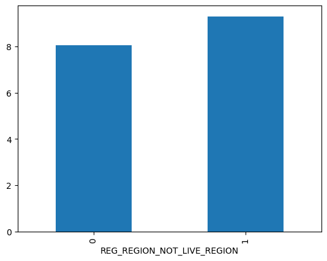

```python
(dff[dff['TARGET']==1]['REG_REGION_NOT_LIVE_REGION'].value_counts()/dff['REG_REGION_NOT_LIVE_REGION'].value_counts()*100).plot(kind='bar')
```

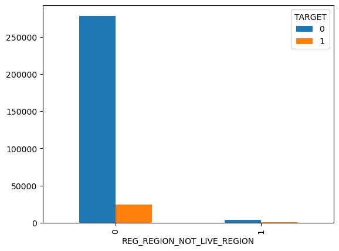

```python
pd.crosstab(dff['REG_REGION_NOT_LIVE_REGION'],dff['TARGET']).plot(kind='bar')
```

HYPOTHESIS Ho : No relation between REG_REGION_NOT_LIVE_REGION and TARGET columns Ha : Relationship exist between REG_REGION_NOT_LIVE_REGION and TARGET columns

```python
stats.chi2_contingency(o)
```

```
Chi2ContingencyResult(statistic=9.394007681743371, pvalue=0.0021769580022904804, dof=1, expected_freq=array([[278404.95411221,  24449.04588779],
       [  4281.04588779,    375.95411221]]))
```

#### p-value 0.002 < 0.05. Hence reject the null hypothesis.

#### Thus there is a significant relationship between REG_REGION_NOT_LIVE_REGION and TARGET columns